# R Notebook

```r
library(knitr)
# A Prefix nulling hook.

# Make sure to keep the default for normal processing.
default_output_hook <- knitr::knit_hooks$get("output")

# Output hooks handle normal R console output.
knitr::knit_hooks$set( output = function(x, options) {

  comment <- knitr::opts_current$get("comment")
  if( is.na(comment) ) comment <- ""
  can_null <- grepl( paste0( comment, "\\s*\\[\\d?\\]" ),
                     x, perl = TRUE)
  do_null <- isTRUE( knitr::opts_current$get("null_prefix") )
  if( can_null && do_null ) {
    # By default R print output aligns at the right brace.
    align_index <- regexpr( "\\]", x )[1] - 1
    # Two cases: start or newline
    re <- paste0( "^.{", align_index, "}\\]")
    rep <- comment
    x <- gsub( re, rep,  x )
    re <- paste0( "\\\n.{", align_index, "}\\]")
    rep <- paste0( "\n", comment )
    x <- gsub( re, rep,  x )
  }

  default_output_hook( x, options )

})

knitr::opts_template$set("kill_prefix"=list(comment=NA, null_prefix=TRUE))
```

**Principles of Data Visualization and Introduction to ggplot2**

I have provided you with data about the 5,000 fastest growing companies in the US, as compiled by Inc. magazine. lets read this in:

```r
inc <- read.csv("https://raw.githubusercontent.com/charleyferrari/CUNY_DATA_608/master/module1/Data/inc5000_data.csv", header= TRUE)
```

And lets preview this data:

```r
head(inc)
```

```
  Rank                         Name Growth_Rate   Revenue
1    1                         Fuhu      421.48 1.179e+08
2    2        FederalConference.com      248.31 4.960e+07
3    3                The HCI Group      245.45 2.550e+07
4    4                      Bridger      233.08 1.900e+09
5    5                       DataXu      213.37 8.700e+07
6    6 MileStone Community Builders      179.38 4.570e+07
                      Industry Employees         City State
1 Consumer Products & Services       104   El Segundo    CA
2          Government Services        51     Dumfries    VA
3                       Health       132 Jacksonville    FL
4                       Energy        50      Addison    TX
5      Advertising & Marketing       220       Boston    MA
6                  Real Estate        63       Austin    TX
```

```r
summary(inc)
```

```
      Rank                          Name       Growth_Rate
 Min.   :   1   (Add)ventures         :   1   Min.   :  0.340
 1st Qu.:1252   @Properties           :   1   1st Qu.:  0.770
 Median :2502   1-Stop Translation USA:   1   Median :  1.420
 Mean   :2502   110 Consulting        :   1   Mean   :  4.612
 3rd Qu.:3751   11thStreetCoffee.com  :   1   3rd Qu.:  3.290
 Max.   :5000   123 Exteriors         :   1   Max.   :421.480
                (Other)               :4995
    Revenue                                  Industry      Employees
 Min.   :2.000e+06   IT Services                 : 733   Min.   :    1.0
 1st Qu.:5.100e+06   Business Products & Services: 482   1st Qu.:   25.0
 Median :1.090e+07   Advertising & Marketing     : 471   Median :   53.0
 Mean   :4.822e+07   Health                      : 355   Mean   :  232.7
 3rd Qu.:2.860e+07   Software                    : 342   3rd Qu.:  132.0
 Max.   :1.010e+10   Financial Services          : 260   Max.   :66803.0
                     (Other)                     :2358   NA's   :12
            City          State
 New York     : 160   CA     : 701
 Chicago      :  90   TX     : 387
 Austin       :  88   NY     : 311
 Houston      :  76   VA     : 283
 San Francisco:  75   FL     : 282
 Atlanta      :  74   IL     : 273
 (Other)      :4438   (Other):2764
```

Think a bit on what these summaries mean. Use the space below to add some more relevant non-visual exploratory information you think helps you understand this data:

**First let’s start with some aggregate counts of the data:**

```r
library(dplyr)
library(kableExtra)

temp <- inc %>%
  select(Industry) %>%
  unique() %>%
  tally() %>%
  rename(Industries = n)

temp <- inc %>%
  select(City) %>%
  unique() %>%
  tally() %>%
  rename(Cities = n) %>%
  bind_cols(temp)

inc %>%
  select(State) %>%
  unique() %>%
  tally() %>%
  rename(States = n) %>%
  bind_cols(temp) %>%
  kable() %>%
  kable_styling()
```

| States | Cities | Industries |
| --- | --- | --- |
| 52 | 1519 | 25 |

**Hmmm. There are 52 states in the data set. I’m guessing there is DC but I wonder if there is an error in the data. I will take a closer look at this:**

```r
unique(inc$State)
```

```
 CA VA FL TX MA TN UT RI SC DC NJ OH WA ME NY CO GA IL AZ NC MD MN OK
 PA CT IN MS WI WY MI MO KS OR NE AL HI NV IA KY ID AK LA DE AR NH VT
 NM SD ND PR MT WV
52 Levels: AK AL AR AZ CA CO CT DC DE FL GA HI IA ID IL IN KS KY LA ... WY
```

**Ahh! There’s Puerto Rico. My hunch about DC was correct. No need to clean that up. Great!**

**I am wondering how some of the variables differ the industry. I will look at the size of the work force and the revenue. I will also construct an output per worker to see which industry is the most productive in economic terms:**

```r
inc %>%
  group_by(Industry) %>%
  mutate(`Output per Worker` = Revenue / Employees) %>%
  summarise(`Avg Employees` = round(mean(Employees, na.rm = TRUE), 0),
            `Avg Revenue` = mean(Revenue, na.rm = TRUE),
            `Avg Output per Worker` = round(mean(`Output per Worker`, na.rm = TRUE), 0),
            Count = n()) %>%
  arrange(desc(`Avg Output per Worker`)) %>%
  kable() %>%
  kable_styling()
```

| Industry | Avg Employees | Avg Revenue | Avg Output per Worker | Count |
| --- | --- | --- | --- | --- |
| Energy | 243 | 126344954 | 1554656 | 109 |
| Computer Hardware | 221 | 270129545 | 817702 | 44 |
| Logistics & Transportation | 260 | 95745161 | 794811 | 155 |
| Food & Beverage | 511 | 98559542 | 618383 | 131 |
| Insurance | 147 | 46758000 | 474966 | 50 |
| Consumer Products & Services | 224 | 73676847 | 466068 | 203 |
| Construction | 156 | 70450802 | 465682 | 187 |
| Manufacturing | 172 | 49546875 | 453524 | 256 |
| Telecommunications | 243 | 56855814 | 449260 | 129 |
| Real Estate | 199 | 30892708 | 434516 | 96 |
| Travel & Hospitality | 372 | 47283871 | 414788 | 62 |
| Retail | 183 | 50529064 | 412555 | 203 |
| Human Resources | 1158 | 47173980 | 395972 | 196 |
| Financial Services | 183 | 50580385 | 394231 | 260 |
| Business Products & Services | 244 | 54705187 | 359097 | 482 |
| Health | 233 | 50319437 | 325199 | 355 |
| Media | 177 | 32266667 | 307144 | 54 |
| Advertising & Marketing | 84 | 16528662 | 306036 | 471 |
| Education | 93 | 13726506 | 296454 | 83 |
| Environmental Services | 199 | 51741176 | 283607 | 51 |
| Security | 562 | 52230137 | 283391 | 73 |
| IT Services | 140 | 28214598 | 270494 | 733 |
| Government Services | 130 | 29748020 | 243596 | 202 |
| Software | 150 | 23802924 | 225989 | 342 |
| Engineering | 276 | 34222973 | 201120 | 74 |

**This is not supprising that the top industries are the most “productive.” They are very capital intensive.**

## Question 1

Create a graph that shows the distribution of companies in the dataset by State (ie how many are in each state). There are a lot of States, so consider which axis you should use. This visualization is ultimately going to be consumed on a ‘portrait’ oriented screen (ie taller than wide), which should further guide your layout choices.

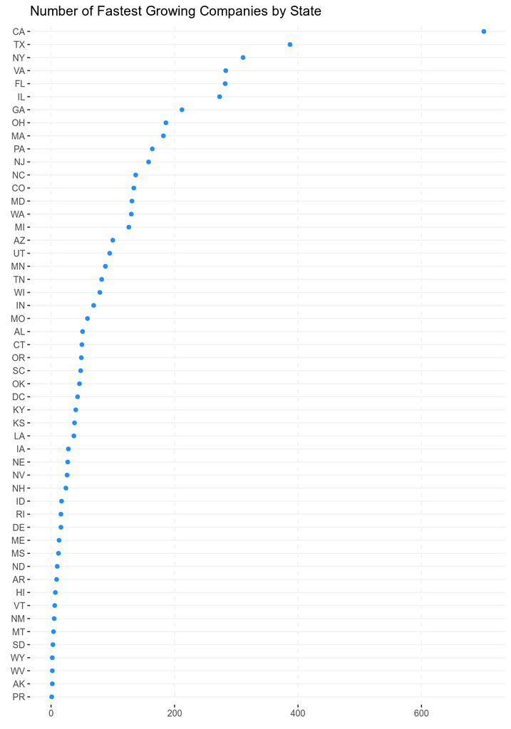

```r
library(ggplot2)

inc %>%
  group_by(State) %>%
  tally() %>%
  ggplot(aes(x = n, y=reorder(State, n))) +
  geom_point(color = "dodger blue") +
  labs(title = "Number of Fastest Growing Companies by State",
       y = element_blank(),
       x = element_blank()) +
  theme(panel.background = element_blank(),
        panel.grid.major = element_line(color = "gray95"),
        panel.grid.major.x = element_line(color = "gray95", linetype="dashed"))
```

## Question 2

Lets dig in on the state with the 3rd most companies in the data set. Imagine you work for the state and are interested in how many people are employed by companies in different industries. Create a plot that shows the average and/or median employment by industry for companies in this state (only use cases with full data, use R’s `complete.cases()` function.) In addition to this, your graph should show how variable the ranges are, and you should deal with outliers.

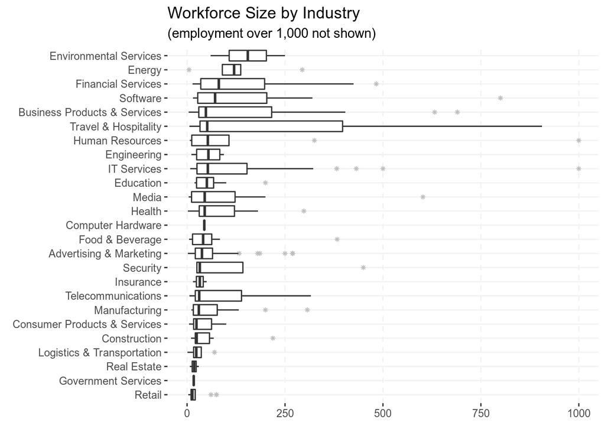

```r
inc %>%
  filter(State == "NY") %>%
  select(Industry, Employees) %>%
  na.omit() %>%
  group_by(Industry) %>%
  mutate(Median = median(Employees)) %>%
  ggplot(aes(x = reorder(Industry, Median), y = Employees)) +
  ylim(0, 1000) +
  labs(title = "Workforce Size by Industry",
       subtitle = "(employment over 1,000 not shown)",
       y = element_blank(),
       x = element_blank()) +
  theme(panel.background = element_blank(),
        panel.grid.major = element_line(color = "gray95"),
        panel.grid.major.x = element_line(color = "gray95", linetype="dashed")) +
  geom_boxplot(outlier.colour="gray", outlier.shape = 8, outlier.size = 0.9) +
  coord_flip()
```

## Question 3

Now imagine you work for an investor and want to see which industries generate the most revenue per employee. Create a chart that makes this information clear. Once again, the distribution per industry should be shown.

**Funny! I guess I think like this investor.**

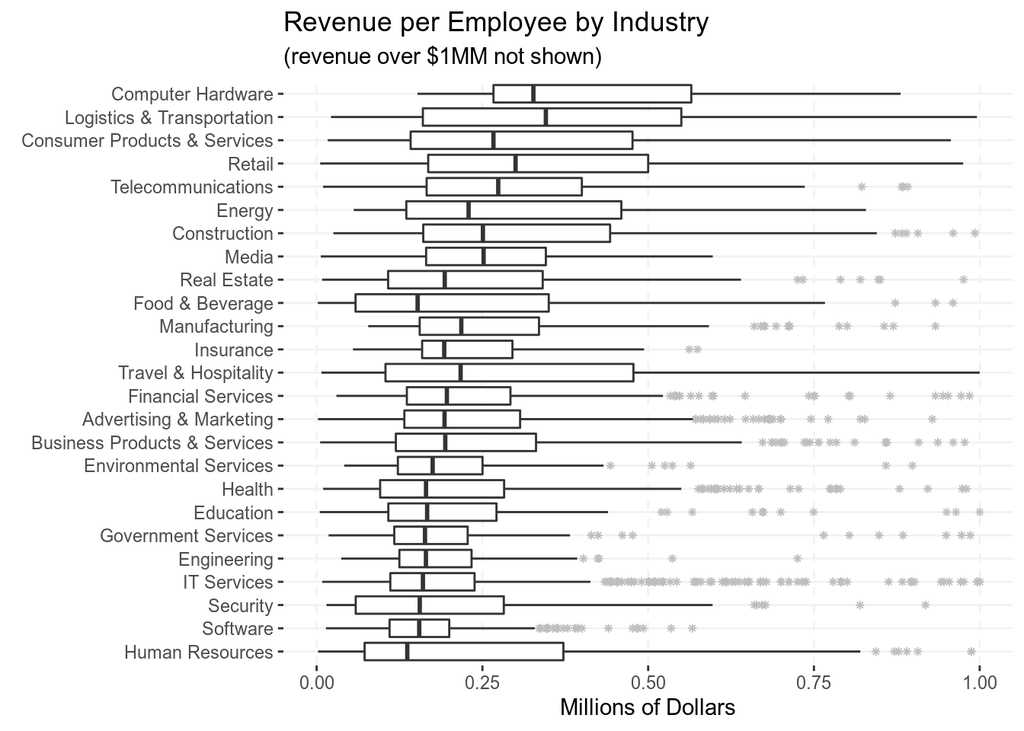

```r
inc %>%
  select(Industry, Revenue, Employees) %>%
  na.omit() %>%
  mutate(`Revenue Per Employee` = Revenue / Employees / 1000000) %>%
  group_by(Industry) %>%
  mutate(Median = median(`Revenue Per Employee`, na.rm = TRUE)) %>%
  ggplot(aes(x = reorder(Industry, Median), y = `Revenue Per Employee`)) +
  ylim(0, 1) +
  labs(title = "Revenue per Employee by Industry",
       subtitle = "(revenue over $1MM not shown)",
       y = "Millions of Dollars",
       x = element_blank()) +
  theme(panel.background = element_blank(),
        panel.grid.major = element_line(color = "gray95"),
        panel.grid.major.x = element_line(color = "gray95", linetype="dashed")) +
  geom_boxplot(outlier.colour="gray", outlier.shape = 8, outlier.size = 0.9) +
  coord_flip()
```

**Available at: https://github.com/mikeasilva/CUNY-SPS/blob/master/DATA608/hw1.rmd**